# Model Performance Report — Pre-Production Defect Risk Scorer

Scoring period: January – March 2026 · Model version 21 · Generated May 27, 2026

Section 1

## Executive Summary

The financial impact of quality failures extends beyond the direct cost of scrapped parts. Each defective run also consumes machine time that produced no good output, requires rework labor often at premium rates, disrupts downstream scheduling when jobs must be remade, and — where defects reach the customer — carries relationship costs that do not appear in any scrap log. The 88 High-risk jobs correctly identified by the model represent quality events where pre-production intervention could have reduced setup risk, allowed material substitution, or prompted operator reassignment before the first part was cut.

705

Jobs Scored

January – March 2026

93

High Risk Flags

13.2% of jobs · 94.6% precision

Section 2

## Scoring Summary

Work Orders by Risk Tier

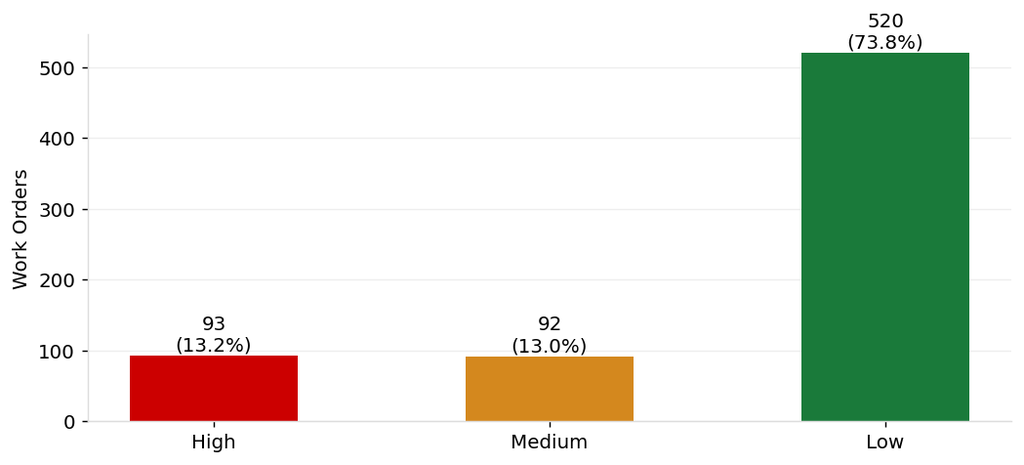

Jobs are scored before production runs. High and Medium tier jobs are flagged for pre-production review.

Distribution of Predicted Defect Probabilities

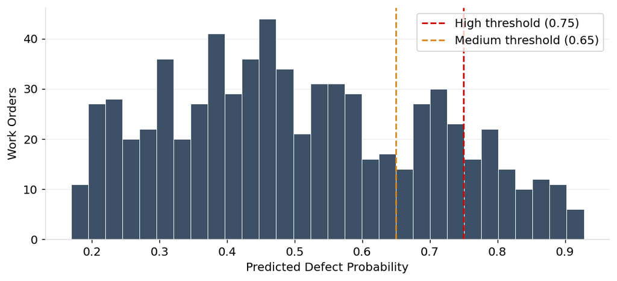

Vertical lines mark the High and Medium risk thresholds. Jobs to the right of each line are flagged at that tier.

Weekly Risk Tier Distribution

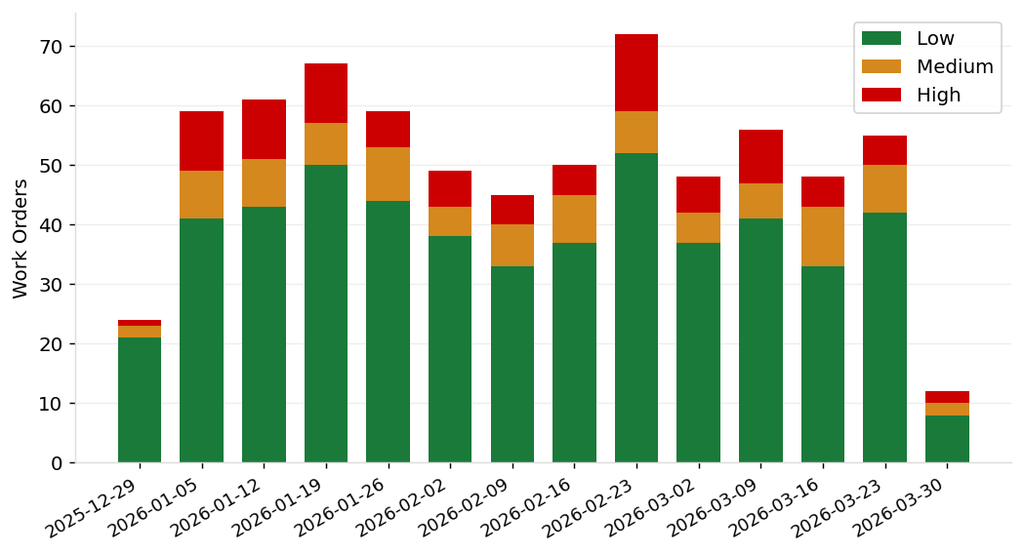

Flagged job volume across the scoring period. Stable distribution indicates consistent model operation.

Section 2.1

## Flagged Jobs Detail

The table below shows the top 25 highest-risk jobs from the scoring period, sorted by predicted defect probability. The Top Driver column identifies the single most influential factor in the model's risk assessment for each job.

[output not shown]

Section 2.2

## Why Jobs Were Flagged

Most Common Top Risk Driver Across Flagged Jobs

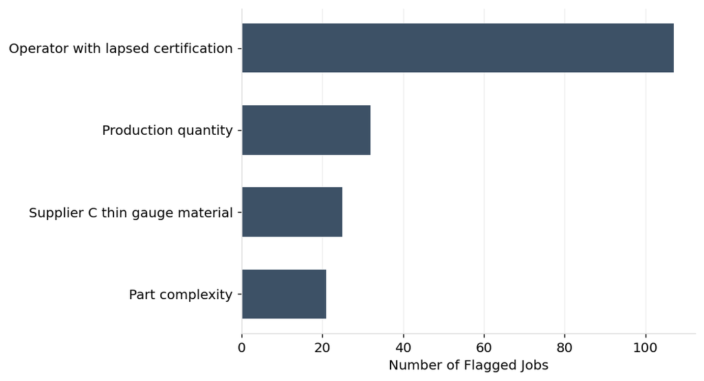

The feature most responsible for each job's risk score, counted across all High and Medium tier flags.

WO-19012 High 92.8% probability ✗ Outcome: Defective

WO-19272 High 92.5% probability ✗ Outcome: Defective

WO-19223 High 92.4% probability ✗ Outcome: Defective

WO-18691 High 91.7% probability ✗ Outcome: Defective

WO-18779 High 91.1% probability ✗ Outcome: Defective

Section 3

## Accuracy Retrospective

Because this scoring period covers historical data with known outcomes, we can evaluate how accurately the model's flags mapped to actual defect events. Precision measures what fraction of flags were correct; recall measures what fraction of all defective jobs were successfully flagged.

| Risk Tier | Threshold | Jobs Flagged | True Positives | False Positives | Precision | Recall |
| --- | --- | --- | --- | --- | --- | --- |
| High | 0.75 | 93 (13.2%) | 88 | 5 | 94.6% | 23.8% |
| Medium | 0.65 | 185 (26.2%) | 158 | 27 | 85.4% | 42.8% |

Precision and Recall by Risk Tier

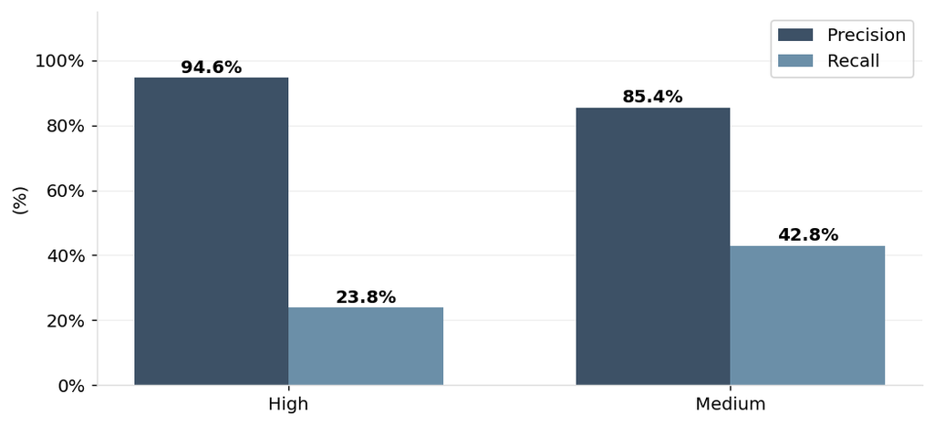

**How to read these numbers:** Precision answers "when the model raised a flag, how often was it right?" Recall answers "of all the jobs that actually failed, how many did the model catch?" High precision with lower recall means the model is conservative — it only flags jobs it is confident about, and misses some defective jobs that don't match the patterns it has learned. As more scoring periods accumulate, these metrics will be tracked over time to monitor whether model performance is stable or degrading.